# Alignment to a reference genome

### Accessing the SIO Vibrio cholerae genome:

First, Brian Hammers paper: https://pubmed.ncbi.nlm.nih.gov/28007852/?from_term=hammer+b+vibrio+cholerae+sequence&from_pos=2

https://mra.asm.org/content/4/6/e01396-16

Link to SIO sequencing project: https://www.ncbi.nlm.nih.gov/nuccore/MIPJ00000000

Then link at the bottom to the Whole Genome Sequencing: https://www.ncbi.nlm.nih.gov/Traces/wgs/MIPJ01?display=contigs

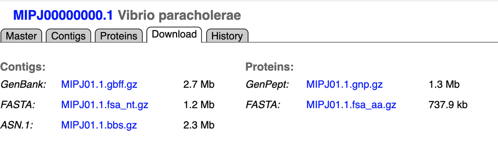

Downloaded the fasta file under contigs. (maybe I should have downloaded a different file for the alignment)

```r
# Unzip the host genome file.
 gunzip MIPJ01.1.fsa_nt.gz
```

### Buidling an Index

```r
# build an index using bowtie2-build
bowtie2-build [options]* (reference_in) (bt2_index_base)
 # To build an index you need to have the reference_in (reference genome) and the bt2_index_base.
# reference_in => comma-separated list of files with ref sequences
# bt2_index_base => write bt2 data to files with this dir/basename
```

```r
# the command I used
bowtie2-build MIPJ01.1.fsa_nt V.cholerae_SIO
```

```r
# Useful commands for help
bowtie2-build --help | less
bowtie2 --help | less
```

### Aligning sample genome (PAcrbR_2) to the reference genome

In general, Bowtie2 is chosen for the genomes of bacteria and other species with a high gene density. The mismatch parameter is set to two, and other parameters are set to default. In general, the total mapped rate should be more than 70%, and the percentage of reads that can be mapped to multiple sites in the reference genome should be less than 10%, if there is no contamination and a correct reference genome is chosen.

```r
bowtie2 [options]* -x <bt2-idx> {-1 <m1> -2 <m2> | -U <r> | --interleaved <i> | -b <bam>} [-S <sam>]
# <bt2-idx>  Index filename prefix (minus trailing .X.bt2).
#  <m1>       Files with #1 mates, paired with files in <m2>.
#  <m2>       Files with #2 mates, paired with files in <m1>.
#  <r>        Files with unpaired reads.
# <i>        Files with interleaved paired-end FASTQ/FASTA reads
# <bam>      Files are unaligned BAM sorted by read name.
# <sam>      File for SAM output (default: stdout)
```

Note: SAM files are human readable text files, and BAM files simply their binary equivalent. BAM files are typically compressed and more efficient for software to work with than SAM.

```r
/opt/anaconda3/bin/bowtie2 -x V.cholerae_SIO -1 PAcrbR_2_1.trim.fq -2 PAcrbR_2_2.trim.fq -S PAcrbR.sam
```

```r
# Aligning the sample genome to the reference genome and creating a sam file for PAcrbR.
bowtie2 -x V.cholerae_SIO  -1 PAcrbR_2_1.fq -2 PAcrbR_2_2.fq  PAcrbR_2.sam
```

```r
# Used samtools view to convert .sam files to .bam files.
/path/to/samtools view -@ numbers -bS /path/to/output.sam > /path/to/output.bam

# /path/to/samtools view - Replace /path/to/samtools/ with your path to samtools
# - view calls the view command within samtools

# -@ number => -@ sets number of threads/processors. Replace number with a number (e.g. 4)

# -bS => Outputs a BAM file /path/to/output.sam > /path/to/output.bam

# Replace /path/to/output.sam with the path to the output sam file you made in the previous step (4C)
# Keep >
# Replace /path/to/output.bam with the path to your output bam file
```

```r
# code I entered into the terminal.
samtools view -S -b PAcrbR.sam > PAcrbR.bam
```

```r
# extracts unmapped reads (not required?)
/path/to/samtools view -@ number -b -f 12 -F 256 /path/to/output.bam > /path/to/unmap.bam
```

```r
#  Sort BAM file to organize paired reads (not required?)
samtools sort -n unmap.bam -o unmap.sorted.bam
```

### Visualization of Mapping status of reads

The Integrative Genomics Viewer (IGV) is recommended for visualizing data from BAM files. (Download IGV)